# Using Scree Plots to find the Optimal value of ‘K’ in K-Means clustering, etc.

## TODO: Look at all text preceded by ‘NOTE:’

This document uses T2-weighted brain MRI data for healthy individual from the dataset healthy.csv.

```r
healthy = read.csv("healthy.csv", header=FALSE)
healthyMatrix = as.matrix(healthy)
healthyVector = as.vector(healthyMatrix)
SumWithinss = sapply(2:10, function(x) sum(kmeans(healthyVector, centers=x, iter.max=1000)$withinss))
SumWithinss
```

```
## [1] 2018.7445  841.3068  467.8845  302.7250  235.9909  192.8943  142.5640
## [8]  124.5709  112.8721
```

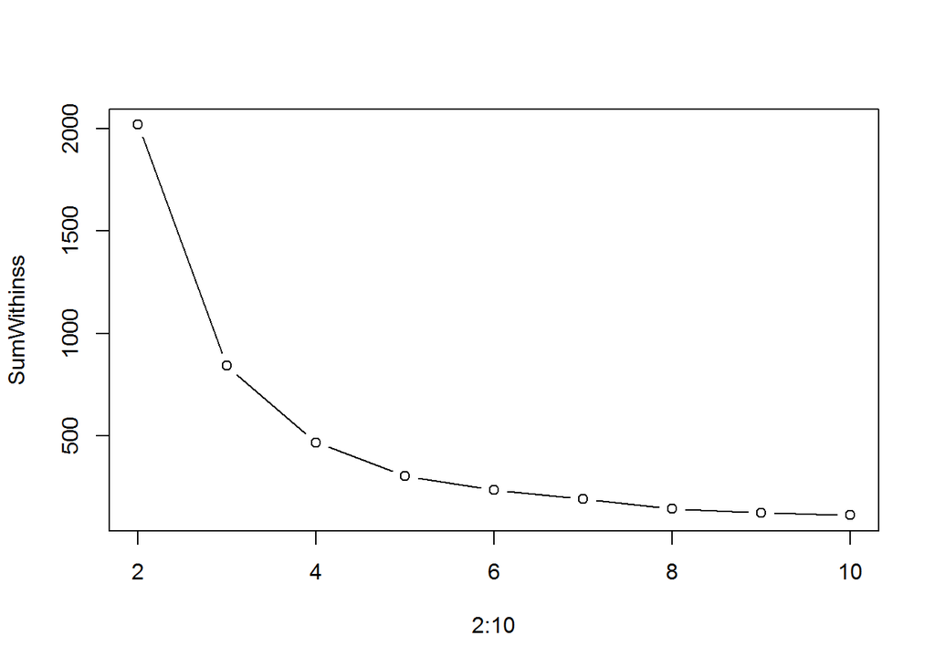

```r
plot(2:10, SumWithinss, type='b')
```

A reliable measure of the strength of particular value of ‘K’ in K-means clustering is the sum (over all clusters) of the within-cluster sum of squares (each within-cluster sum of squares is the sum (over all elements in the cluster) of squared deviations from the cluster’s centroid) for that value of K.

A scree plot displays the sum of within-cluster sum of squares against the value of K. The scree plot reveals that the sum of within-cluster sum of squares drops as the value of K increases. This should make sense because as the number of clusters increases, the size of each cluster is smaller and observations will be closer to their respective centroids. A good choice of K is the smallest value of K beyond which any increase in K doesn’t lead to much of an appreciable decrease in the sum of within-cluster sum of squares. Small values of K are good because fewer clusters allow for a simpler clustering model and fewer clusters to pigeonhole into when doing subsequent analysis.

### Computing within-cluster sum of squares ‘manually’

Below is a function (using nested loops) that computes within-cluster sum of squares manually. Looking at the code you’ll see some useful teaching points.

```r
KMC = kmeans(healthyVector, centers = 5)

verifySS<-function() {
  spl = split(healthyVector, KMC$cluster)
  cmp_withinClustSS = numeric(5)
  for(p in seq(spl)){
    tot = 0
    listItem = unlist(spl[p])
    for(val in listItem){
      tot = tot + ((val - KMC$centers[p])^2)
    }
    cmp_withinClustSS[p] = tot
  }
  return (cmp_withinClustSS)
}
verifySS()
```

```
## [1] 45.63754 48.04392 84.64093 64.69361 57.57829
```

```r
KMC$withinss
```

```
## [1] 45.63754 48.04392 84.64093 64.69361 57.57829
```